# 02c - Longitudinal Analysis of Cannabis-related Temperatures (Gavage Administration)

Laura Saba

2022-01-13

Please note that there are no control mice for gavage administration in the January experiment.

## Data Disctionary

| Variable | Definition | Factor Levels |
| --- | --- | --- |
| date | The actual date associated with record | Dates for July & January |
| study_day | An ordinal number describing the study day. For each study day, there are 72 records | N/A |
| time_period | Variable describing the dose period. Each time period can be either a “dose #” or a “nonDose #”. Example: Dose 1 & nonDose 1 | N/A |
| time_window | Variable describing aggregated time windows for temp record collection. Original data had temp data recorded by the minute. These data were then averaged over 6 minute windows, and then aggregated in … | pre dose dose post dose 1 post dose 2 post dose 3 post dose 4 post dose 5 post dose 6 |
| sample_id | Unique identifier for each mouse | NA |
| temp | Aggregated temperature measurement for a given time_window | N/A |
| mouse | Number assigned to a given mouse | N/A |
| admin | Method used to administer cannabis to mouse | Free IP Gavage |
| dose | Variable describing the dose level for a given mouse | Control Low Medium High |
| day_type | Variable describing whether or not a dose of cannabis was administered | dose no dose |
| round | Variable that serves as a wrapper for an administration cycle (i.e. encompasses a dose day and a no dose day) | N/A |

### Chronic effects of cannabis

For this analysis, I compared the temperature at during the ‘predose’ window across dosage groups using time in days as a continuous covariate. Data from dosing days and non-dosing days were included since we are only looking at the predose window.

**Two-Way ANOVA Results**

|  | Sum Sq | Mean Sq | NumDF | DenDF | F value | Pr(>F) |
| --- | --- | --- | --- | --- | --- | --- |
| dose | 0.0964646 | 0.0482323 | 2 | 3.273454 | 0.2879752 | 0.7669998 |
| study_day | 4.2620535 | 4.2620535 | 1 | 63.000000 | 25.4469595 | 0.0000041 |
| dose:study_day | 1.0249445 | 0.5124722 | 2 | 63.000000 | 3.0597598 | 0.0539268 |

**Comparing Slopes, i.e., study day trends, across dosage groups**

| dose | study_day.trend | SE | df | lower.CL | upper.CL |
| --- | --- | --- | --- | --- | --- |
| Low | -0.0928587 | 0.0192072 | 63 | -0.1312412 | -0.0544762 |
| Med | -0.0271586 | 0.0192072 | 63 | -0.0655411 | 0.0112239 |
| High | -0.0478021 | 0.0192072 | 63 | -0.0861846 | -0.0094196 |

| contrast | estimate | SE | df | t.ratio | p.value |
| --- | --- | --- | --- | --- | --- |
| Low - Med | -0.0657001 | 0.0271631 | 63 | -2.4187313 | 0.0478686 |
| Low - High | -0.0450566 | 0.0271631 | 63 | -1.6587473 | 0.2291083 |
| Med - High | 0.0206435 | 0.0271631 | 63 | 0.7599841 | 0.7287348 |

**Model-based dose group estimates**

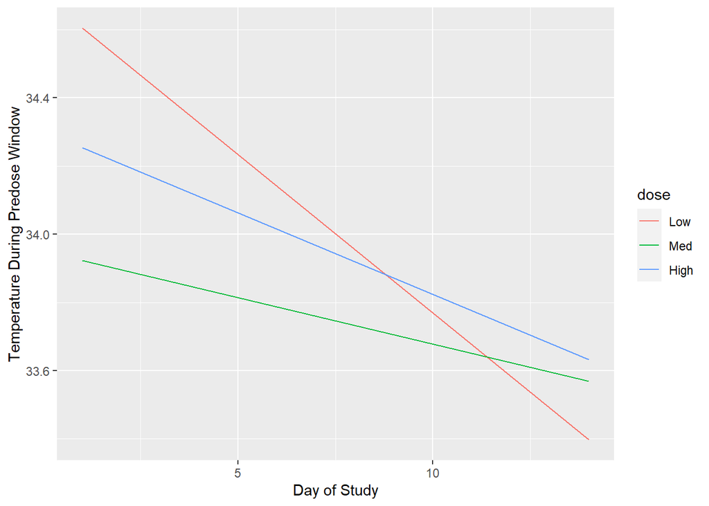

**Observed data**

Each line represents an individual mice.

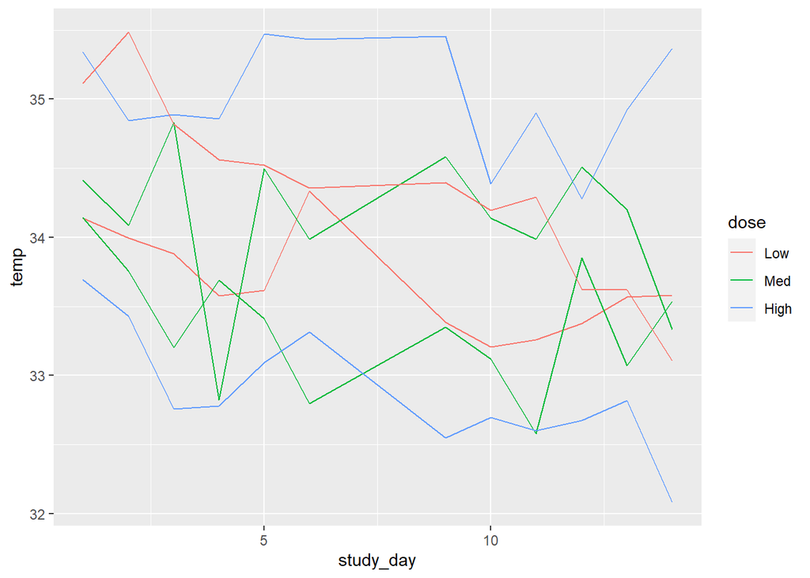

Based on my understanding of the study design, the 3 dosage groups should not differ in temperature at day 1 during the predose window because none of the animals would have received any cannabis prior to that time point.

Since this graphic made it look like the dosage groups differed at day 1, I tested that directly.

Omnibus p-value for dosage effect: 0.906

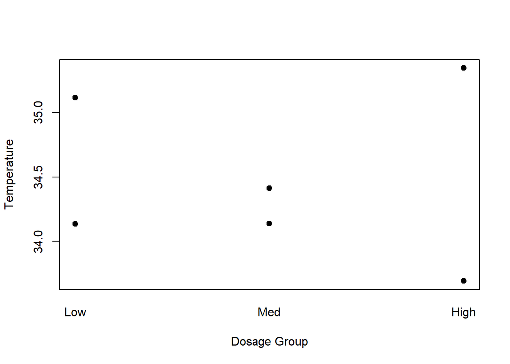

There are no significant differences in starting temperature between the three dose levels.

| contrast | estimate | SE | df | t.ratio | p.value |
| --- | --- | --- | --- | --- | --- |
| Low - Med | 0.3485714 | 0.7882181 | 3 | 0.4422271 | 0.9011736 |
| Low - High | 0.1078571 | 0.7882181 | 3 | 0.1368367 | 0.9897655 |
| Med - High | -0.2407143 | 0.7882181 | 3 | -0.3053905 | 0.9507146 |

## Acute Effects of Cannabis on Temperature

To examine the acute effects (i.e., within a treatment day) of cannabis, data points were limited to those collected during a ‘dose’ day.

### Initial Acute Effect of Cannabis on Temperature

First, the initial acute effects of cannabis were assessed by only focusing on changes in temperature across different windows of time on the first study day that mice were exposed to cannabis

**Two-Way ANOVA Results**

|  | Sum Sq | Mean Sq | NumDF | DenDF | F value | Pr(>F) |
| --- | --- | --- | --- | --- | --- | --- |
| dose | 0.1328044 | 0.0664022 | 2 | 2.999999 | 0.4503222 | 0.6744929 |
| time_window | 11.4185381 | 1.6312197 | 7 | 69.000000 | 11.0625024 | 0.0000000 |
| dose:time_window | 4.2532917 | 0.3038066 | 14 | 69.000000 | 2.0603360 | 0.0251586 |

Based on the significant interaction effect, the model suggest that the effect of the within-day time window differs between doses.

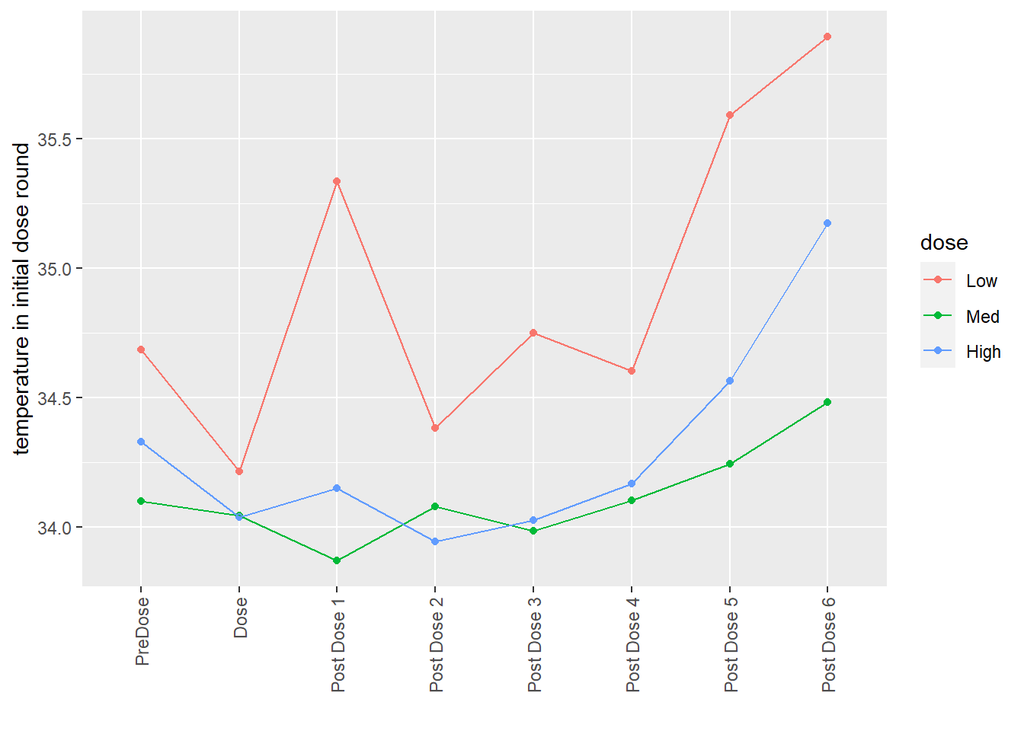

| contrast | dose | estimate | SE | df | t.ratio | p.value |
| --- | --- | --- | --- | --- | --- | --- |
| Dose - PreDose | Low | -0.4689286 | 0.271528 | 69 | -1.7269992 | 0.0886423 |
| Post Dose 1 - PreDose | Low | 0.6503571 | 0.271528 | 69 | 2.3951757 | 0.0193312 |
| Post Dose 2 - PreDose | Low | -0.3021429 | 0.271528 | 69 | -1.1127505 | 0.2696774 |
| Post Dose 3 - PreDose | Low | 0.0657143 | 0.271528 | 69 | 0.2420167 | 0.8094851 |
| Post Dose 4 - PreDose | Low | -0.0814286 | 0.271528 | 69 | -0.2998902 | 0.7651625 |
| Post Dose 5 - PreDose | Low | 0.9060714 | 0.271528 | 69 | 3.3369361 | 0.0013673 |
| Post Dose 6 - PreDose | Low | 1.2085714 | 0.271528 | 69 | 4.4510019 | 0.0000320 |

| contrast | dose | estimate | SE | df | t.ratio | p.value |
| --- | --- | --- | --- | --- | --- | --- |
| Dose - PreDose | Med | -0.0569643 | 0.271528 | 69 | -0.2097916 | 0.8344485 |
| Post Dose 1 - PreDose | Med | -0.2307143 | 0.271528 | 69 | -0.8496889 | 0.3984367 |
| Post Dose 2 - PreDose | Med | -0.0214286 | 0.271528 | 69 | -0.0789185 | 0.9373259 |
| Post Dose 3 - PreDose | Med | -0.1160714 | 0.271528 | 69 | -0.4274751 | 0.6703645 |
| Post Dose 4 - PreDose | Med | 0.0021429 | 0.271528 | 69 | 0.0078918 | 0.9937261 |
| Post Dose 5 - PreDose | Med | 0.1432143 | 0.271528 | 69 | 0.5274385 | 0.5995811 |
| Post Dose 6 - PreDose | Med | 0.3800000 | 0.271528 | 69 | 1.3994876 | 0.1661466 |

| contrast | dose | estimate | SE | df | t.ratio | p.value |
| --- | --- | --- | --- | --- | --- | --- |
| Dose - PreDose | High | -0.2917857 | 0.271528 | 69 | -1.0746065 | 0.2862944 |
| Post Dose 1 - PreDose | High | -0.1789286 | 0.271528 | 69 | -0.6589693 | 0.5121087 |
| Post Dose 2 - PreDose | High | -0.3846429 | 0.271528 | 69 | -1.4165866 | 0.1611029 |
| Post Dose 3 - PreDose | High | -0.3017857 | 0.271528 | 69 | -1.1114352 | 0.2702389 |
| Post Dose 4 - PreDose | High | -0.1596429 | 0.271528 | 69 | -0.5879426 | 0.5584902 |
| Post Dose 5 - PreDose | High | 0.2360714 | 0.271528 | 69 | 0.8694185 | 0.3876326 |
| Post Dose 6 - PreDose | High | 0.8460714 | 0.271528 | 69 | 3.1159644 | 0.0026715 |

### Acute Effect of Cannabis on Temperature After Chronic Exposure to Cannabis

**Two-Way ANOVA Results**

|  | Sum Sq | Mean Sq | NumDF | DenDF | F value | Pr(>F) |
| --- | --- | --- | --- | --- | --- | --- |
| dose | 0.0269399 | 0.0134699 | 2 | 3 | 0.0555393 | 0.9469246 |
| time_window | 24.0656917 | 3.4379560 | 7 | 69 | 14.1753985 | 0.0000000 |
| dose:time_window | 1.0969491 | 0.0783535 | 14 | 69 | 0.3230676 | 0.9889615 |

The two-way ANOVA results suggest that there are is a significant difference across time windows and that difference is consistent across dosage group.

**Time Window Effect in Last Round of Dose Stratified by Dose**

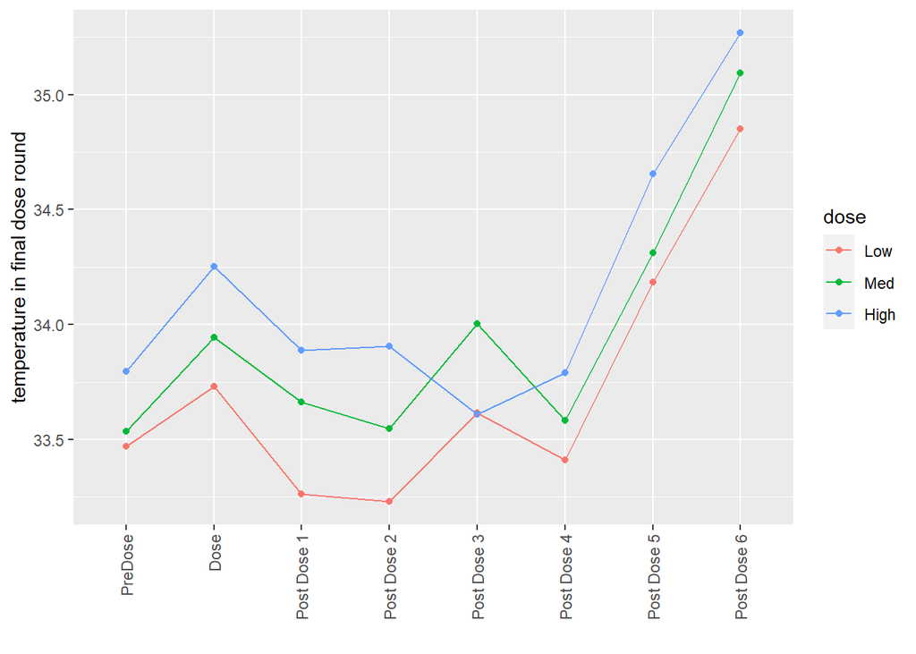

| contrast | dose | estimate | SE | df | t.ratio | p.value |
| --- | --- | --- | --- | --- | --- | --- |
| Dose - PreDose | Low | 0.2621429 | 0.3482311 | 69 | 0.7527842 | 0.4541403 |
| Post Dose 1 - PreDose | Low | -0.2053571 | 0.3482311 | 69 | -0.5897152 | 0.5573078 |
| Post Dose 2 - PreDose | Low | -0.2392857 | 0.3482311 | 69 | -0.6871464 | 0.4942936 |
| Post Dose 3 - PreDose | Low | 0.1460714 | 0.3482311 | 69 | 0.4194670 | 0.6761780 |
| Post Dose 4 - PreDose | Low | -0.0582143 | 0.3482311 | 69 | -0.1671714 | 0.8677241 |
| Post Dose 5 - PreDose | Low | 0.7146429 | 0.3482311 | 69 | 2.0522088 | 0.0439453 |
| Post Dose 6 - PreDose | Low | 1.3825000 | 0.3482311 | 69 | 3.9700650 | 0.0001738 |

| contrast | dose | estimate | SE | df | t.ratio | p.value |
| --- | --- | --- | --- | --- | --- | --- |
| Dose - PreDose | Med | 0.4092857 | 0.3482311 | 69 | 1.1753280 | 0.2439033 |
| Post Dose 1 - PreDose | Med | 0.1264286 | 0.3482311 | 69 | 0.3630594 | 0.7176704 |
| Post Dose 2 - PreDose | Med | 0.0125000 | 0.3482311 | 69 | 0.0358957 | 0.9714692 |
| Post Dose 3 - PreDose | Med | 0.4671429 | 0.3482311 | 69 | 1.3414738 | 0.1841653 |
| Post Dose 4 - PreDose | Med | 0.0457143 | 0.3482311 | 69 | 0.1312757 | 0.8959392 |
| Post Dose 5 - PreDose | Med | 0.7753571 | 0.3482311 | 69 | 2.2265593 | 0.0292439 |
| Post Dose 6 - PreDose | Med | 1.5571429 | 0.3482311 | 69 | 4.4715793 | 0.0000297 |

| contrast | dose | estimate | SE | df | t.ratio | p.value |
| --- | --- | --- | --- | --- | --- | --- |
| Dose - PreDose | High | 0.4567857 | 0.3482311 | 69 | 1.3117316 | 0.1939584 |
| Post Dose 1 - PreDose | High | 0.0900000 | 0.3482311 | 69 | 0.2584491 | 0.7968297 |
| Post Dose 2 - PreDose | High | 0.1092857 | 0.3482311 | 69 | 0.3138310 | 0.7545962 |
| Post Dose 3 - PreDose | High | -0.1860714 | 0.3482311 | 69 | -0.5343332 | 0.5948285 |
| Post Dose 4 - PreDose | High | -0.0060714 | 0.3482311 | 69 | -0.0174351 | 0.9861399 |
| Post Dose 5 - PreDose | High | 0.8578571 | 0.3482311 | 69 | 2.4634710 | 0.0162576 |
| Post Dose 6 - PreDose | High | 1.4703571 | 0.3482311 | 69 | 4.2223606 | 0.0000725 |